# Part II - Effects of borrowers' attributes on borrowers' rate

## by Quadri Naheem

## Investigation Overview

In this investigation, my aim is to find out loan borrowers features that can be used to predict borrower's interest rate. The main focus was on the influence of EstimatedLoss, EmploymentStatus, IsBorrowerHomeowner, and IncomeRange.

## Dataset Overview

The data consisted of BorrowerRate and attributes of 113,937 Prosper loan borrowers. The attributes include EstimatedLoss, EmploymentStatus, IsBorrowerHomwowner, IncomeRange and others. 31,262 data points were removed from the analysis due to inconsistencies and to ensure adequate standardization.

## Distribution of BorrowerRate

BorrowerRate distribution is bimodal and slightly skewed to the right, with one large peak between 0.14 and 0.16, and a second large peak between 0.30 - 0.32

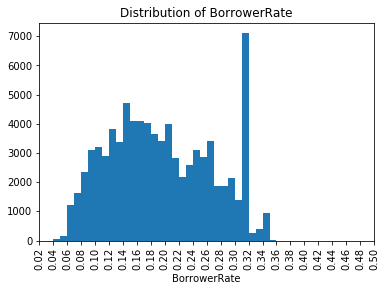

## Distribution of EstimatedLoss

Plotted on a logarithmic scale, EstimatedLoss distribution is unimodal and has its peak between 0.05 and 0.06

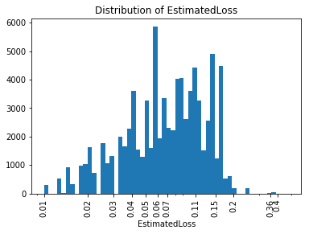

## BorrowerRate vs. EstimatedLoss

From the scatter plot, it can be deduced that BorrowerRate and EstimatedLoss are very highly positively correlated. Higher estimated loss from a borrower will likely mean higher interest rate will be offered to the borrower

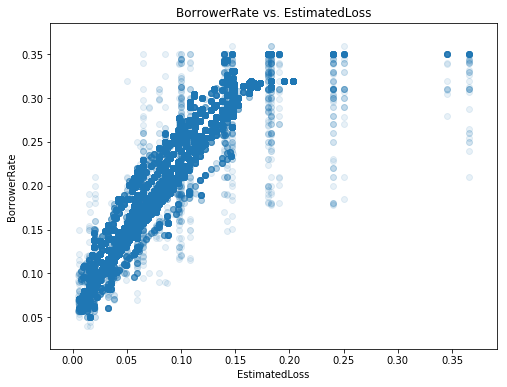

## BorrowerRate vs. EmploymentStatus, IsBorrowerHomeowner and IncomeRange

The plots reveal that a relationship exists between the borrowers rate and borrowers employment status as the borrowers employed received less median interest rate, while the ones that are not employed received high median interest rate. In that regard, borrowers that are home owners also received lower median interest rates compared to those that are not home owners. In the same way, borrowers that have high income received lesser median interest rate compared to those that received lower income

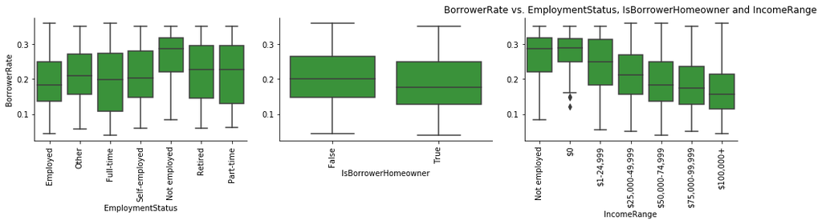